# SNA_Abgabe_LucasKrannich

Lucas Krannich

2025-07-08

# Social Network Analysis - Wikispeedia - Lucas Krannich

Das vorliegende Projekt wurde in Einzelarbeit statt in Gruppenarbeit durchgeführt. Im Folgenden findet eine Netzwerkanalyse des Datensatzes „Wikispeedia Navigation Paths“ statt. Der Datensatz enthält aufgezeichnete Navigationspfade des Browserspiels „Wikispeedia“. In Wikispeedia werden die Benutzer aufgefordert, von einer bestimmten Quelle zu einem bestimmten Zielartikel zu navigieren, indem sie nur Wikipedia-Links anklicken.

Auf den zugrunde liegenden Datensatz kann über die Stanford Large Network Dataset Collection (SNAP) zugegriffen werden. https://snap.stanford.edu/data/wikispeedia.html

Das vorliegende Projekt orientiert sich grundlegend an dem folgenden Artikel: https://studentwork.prattsi.org/infovis/labs/exploring-the-network-behind-wikispeedia/

Die starke Orientierung an dem verlinkten Artikel ist unter anderem damit zu begründen, dass der Autor eher zu den „fachlich schwächeren Studenten“ gehört, mit diesem Projekt allerdings eine Herausforderung gesucht wurde, um sich selbst weiterzuentwickeln.

Im zugrundeliegenden Artikel werden neben RStudio auch die Tools „Open Refine“ und „Gephi“ genutzt. In der vorliegenden Arbeit wird von der Nutzung von Gephi abgesehen und es wird lediglich Open Refine genutzt.

OpenRefine ist ein Tool zur Datenbereinigung und -aufbereitung. Es unterstützt den Benutzer hierbei mit einer grafischen Oberfläche. Im Folgenden wird im Kapitel Data Cleaning erneut darauf eingegangen.

## Imports (Data & Libraries)

```r
library(tidyverse)
library(igraph)
library(ggraph)
library(tidygraph)
```

TSV-Datei einlesen & Info zu Daten ausgeben

```r
df <- read_tsv("C:/Users/Krann/GitHub/SNA/Wikispeedia-paths-finished.tsv", col_names = TRUE)
```

```r
head(df)
```

```
## # A tibble: 6 × 5
##   hashedIpAddress   timestamp durationInSec path                          rating
##   <chr>                 <dbl>         <dbl> <chr>                         <chr>
## 1 3824310e536af032 1344753412            88 14th_century;Europe;Africa;A… 3
## 2 64dd5cd342e3780c 1265613925            37 14th_century;Renaissance;Anc… NULL
## 3 5295bca242be81fe 1372890414           110 14th_century;Europe;North_Am… NULL
## 4 36dabfa133b20e3c 1249525912           112 14th_century;China;Gunpowder… 2
## 5 08888b1b428dd90e 1232241510            74 14th_century;Time;Light;Rain… 3
## 6 390ae528683f78ab 1250727252            66 14th_century;Time;Astronomy;… NULL
```

## Data Cleaning

Trotz vorheriger Bereinigung enthält der Datensatz noch „NULL“-Werte. Diese sind in der Spalte „Rating“ wiederzufinden. Allerdings handelt es sich hierbei nicht um klassische 0-Werte, sondern um String-Werte. Im nächsten Schritt werden alle Zeilen, die einen Null-Wert enthalten, entfernt. Die Null-Werte werden in R entfernt. In OpenRefine wäre dies auch möglich gewesen, es wurde sich aber dagegen entschieden, da der Umgang und die Arbeit mit OpenRefine teilweise nicht so intuitiv sind und eine Bereinigung in R schneller geht. Auf eine erneute Verwendung von OpenRefine würde in zukünftigen Projekten nur zurückgegriffen werden, wenn zuvor bereits alle Bereinigungsschritte klar sind, da die Verwendung von OpenRefine sonst eher umständlich ist.

```r
df <- df %>%
  filter(rating != "NULL")

nrow(df)
```

```
## [1] 13527
```

Der Datensatz wurde von ca. 50.000 Zeilen auf 13.527 Zeilen herunterreduziert.

```r
head(df)
```

```
## # A tibble: 6 × 5
##   hashedIpAddress   timestamp durationInSec path                          rating
##   <chr>                 <dbl>         <dbl> <chr>                         <chr>
## 1 3824310e536af032 1344753412            88 14th_century;Europe;Africa;A… 3
## 2 36dabfa133b20e3c 1249525912           112 14th_century;China;Gunpowder… 2
## 3 08888b1b428dd90e 1232241510            74 14th_century;Time;Light;Rain… 3
## 4 1c6947833f8d7a1e 1345522466            75 14th_century;Time;Light;Rain… 1
## 5 067ebbe12b292e09 1347307547            47 14th_century;Time;Isaac_Newt… 2
## 6 50a37fed218932d3 1349365685            57 14th_century;Edward_III_of_E… 2
```

Alle Null-Werte wurden entfernt. Der Datensatz ist jetzt vollständig bereinigt.

## Vorbereitung Netzwerk Analyse

Im ersten Schritt wird die Funktion Extract Edges erstellt. Die Navigationspfade aus dem Datensatz werden ausgelesen, aufgeteilt und gespeichert. Pfade mit weniger als 2 Werten werden ignoriert. Das liegt daran, dass der Startpunkt somit auch der Endpunkt wäre. Anschließend wird eine gerichtete Edgelist erstellt.

```r
extract_edges <- function(path_string) {
  pages <- unlist(strsplit(path_string, ";"))
  if (length(pages) < 2) return(NULL)
  edges <- data.frame(
    source = pages[-length(pages)],
    target = pages[-1]
  )
  return(edges)
}
```

Die Funktion extract_edges wird auf den Datensatz angewandt. Die Variable edge_list enthält nun die gerichtete Edge-List für alle Navigationspfade des Datensatzes.

```r
edge_list <- df %>%
  pull(path) %>%
  map_dfr(extract_edges)
```

Die Edge-List wird entsprechend der Häufigkeit der einzelnen Pfade aggregiert und in der Variable weighted_edges gespeichert.

```r
weighted_edges <- edge_list %>%
  count(source, target, name = "weight")
```

Da das Ziel der Analyse die Erstellung eines ungerichteten Graphen ist, wird die „Gerichtetheit“ der Edge-List aufgehoben.

```r
g <- graph_from_data_frame(weighted_edges, directed = FALSE)
```

Berechnung der 2 Zentralitätsmaße „Betweenness“ und „Degree“.

Die Betweenness bezieht sich im vorliegenden Fall auf die Vermittler-Funktion eines Knotens. Eine hohe Betweenness zeigt, wie oft ein Knoten als Zwischenschritt genutzt wurde.

Der Degree zeigt, mit wie vielen weiteren Wikipedia-Seiten eine bestimmte Wikipedia-Seite verlinkt ist.

```r
V(g)$betweenness <- betweenness(g)
V(g)$degree <- degree(g)
```

## “Naiver Plot”

Im Folgenden wird zunächst der erste Plot des Netzwerks dargelegt, um den Stand nach der Datenbereinigung zu visualisieren.

```r
plot_unfiltered_network <- ggraph(g, layout = "fr") +
  # Kanten: Gewicht → Breite, Farbe: dezent
  geom_edge_link(aes(width = weight), alpha = 0.2, color = "gray40") +
  scale_edge_width(range = c(0.2, 3)) +

  # Knoten: Größe nach Betweenness, Farbe nach Degree
  geom_node_point(aes(size = betweenness, color = degree), show.legend = TRUE) +
  scale_size_continuous(range = c(1, 10)) +
  scale_color_viridis_c(option = "B", direction = -1) +

  # Knotenbeschriftung – stark eingeschränkt zur Vermeidung von Überladung
  geom_node_text(aes(label = name), repel = TRUE, size = 2.5, max.overlaps = 10) +

  theme_void() +
  labs(
    title = "Wikispeedia Netzwerkvisualisierung (ungesäubert)",
    subtitle = "Größe = Betweenness Centrality | Farbe = Degree | Keine Filterung"
  ) +
  theme(
    legend.position = "right",
    plot.title = element_text(hjust = 0.5, face = "bold", size = 16),
    plot.subtitle = element_text(hjust = 0.5, size = 12)
  )
```

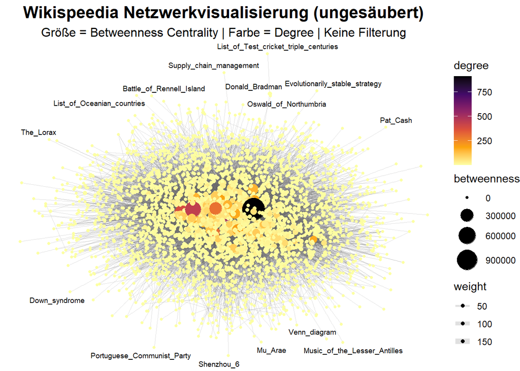

```r
print(plot_unfiltered_network)
```

Da es sich nach dem Data Cleaning immer noch um ein sehr umfangreiches Netzwerk handelt, wird es auf den Degree gefiltert und Knoten, deren Degree unter dem festgelegten Schwellenwert „60“ liegt, werden in der weiteren Analyse nicht weiter beachtet. Dieses Vorgehen schafft einerseits ein übersichtlicheres Netzwerk, da das Rauschen im Datensatz verringert wird. Andererseits wird der Fokus der Analyse stärker auf die Kernstruktur gelegt, da lediglich strukturell relevante Knoten in die Analyse mit einbezogen werden. Zudem wird eine übersichtlichere visuelle Darstellung ermöglicht.

Eine alternative Filterung auf die Betweenness wurde in der vorliegenden Analyse nicht durchgeführt.

```r
min_degree_threshold <- 60


g_filtered <- g %>%
  delete_vertices(V(g)$degree < min_degree_threshold) # Knoten mit weniger als X Verbindungen entfernen


cat("Anzahl der Knoten im ursprünglichen Graphen:", vcount(g), "\n")
```

```
## Anzahl der Knoten im ursprünglichen Graphen: 3724
```

```r
cat("Anzahl der Knoten im gefilterten Graphen (Degree-Filter):", vcount(g_filtered), "\n")
```

```
## Anzahl der Knoten im gefilterten Graphen (Degree-Filter): 94
```

Erneute Berechnung der Betweenness- und Degree-Werte auf Basis des gefilterten Netzwerks. Dies ist notwendig, weil sich durch das Entfernen von Knoten im vorherigen Schritt auch die Struktur des Netzwerks verändert und damit die relativen zentralen Rollen der verbliebenen Knoten neu zu bestimmen sind.

```r
V(g_filtered)$betweenness <- betweenness(g_filtered)
V(g_filtered)$degree <- degree(g_filtered)
```

## Visualisierung des gefilterten Netzwerks

```r
plot_filtered_network <- ggraph(g_filtered, layout = "fr") +
  # Kanten: Breite nach Gewicht, Farbe dunkelgrün
  geom_edge_link(aes(width = weight), alpha = 0.3, color = "darkgreen") + # alpha leicht erhöht
  scale_edge_width(range = c(0.5, 5)) + # Bereich für Kantenbreite angepasst für bessere Sichtbarkeit

  # Knoten: Größe nach Betweenness, Farbe nach Degree
  geom_node_point(aes(size = betweenness, color = degree), show.legend = TRUE) +
  scale_size_continuous(range = c(3, 15)) + # Bereich für Knotengröße angepasst für bessere Sichtbarkeit
  scale_color_viridis_c(option = "B", direction = -1) + # Eine bessere Farbskala (viridis)
  geom_node_text(aes(label = name), repel = TRUE, size = 3, max.overlaps = 20) + # Knotenbeschriftungen

  theme_void() + # Entfernt Achsen und Hintergrund
  labs(
    title = "Wikispeedia Netzwerkvisualisierung (gefiltert)",
    subtitle = "Größe = Betweenness Centrality | Farbe = Degree | Filter: Degree > 60"
  ) +
  theme(
    legend.position = "right", # Legendenposition anpassen
    plot.title = element_text(hjust = 0.5, face = "bold", size = 16),
    plot.subtitle = element_text(hjust = 0.5, size = 12)
  )
```

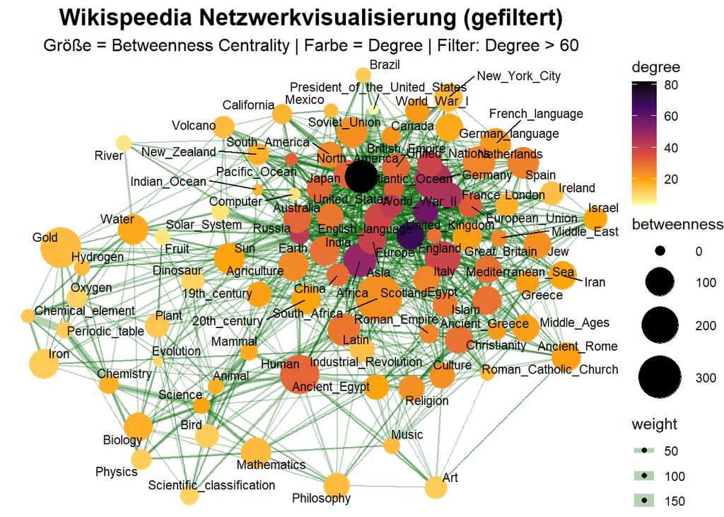

```r
print(plot_filtered_network)
```

Das gefilterte Netzwerk ist bereits besser interpretierbar. Sowohl die Betweenness als auch der Degree der Knoten sind ersichtlich und bieten einen klaren Einblick in die Relevanz der Knoten. Jedoch ist hervorzuheben, dass die Gewichtung der Kanten in der gewählten Darstellung Optimierungspotenzial hat, da diese in der visuellen Darstellung kaum erkenntlich ist. Zudem liegt im vorliegenden Fall die Problematik vor, dass mit einem Gewinn an Übersichtlichkeit die Gefahr besteht, Informationen zu verlieren. Um die visuellen Erkenntnisse zu unterstützen, werden im Folgenden die Knoten gemäß ihrer Betweenness, Degree und Gewichtungswerte tabellarisch dargestellt.

## Tabellarische Darstellung

Aufgrund des Umfangs der Daten werden im vorliegenden Markdown nur die Vorschau auf die Tabellen (Tabellenköpfe) dargestellt.

```r
node_metrics_df <- as_data_frame(g_filtered, what = "vertices")
```

```r
node_metrics_df_sorted_betweenness <- node_metrics_df %>%
  arrange(desc(betweenness))

head(node_metrics_df_sorted_betweenness, n= 10)
```

```
##                        name betweenness degree
## South_Africa   South_Africa    371.3387     23
## Gold                   Gold    254.8993     15
## Human                 Human    229.4843     31
## Germany             Germany    218.1664     45
## Italy                 Italy    174.0013     39
## United_States United_States    149.6649     82
## Africa               Africa    148.4375     50
## Netherlands     Netherlands    138.9704     25
## Latin                 Latin    138.2021     28
## Spain                 Spain    128.1497     26
```

Vor allem die Wikipedia-Seiten „South_Africa“, „Gold“ und „Human“ dienen als Vermittler. Sie werden also oft als Zwischenschritt für die Navigation zur Ziel-Wikipedia-Seite genutzt. Dies ist darauf zurückzuführen, dass Sie möglicherweise thematisch breit verbunden sind und als Knotenpunkt für viele unterschiedliche Themenbereiche dienen.

```r
node_metrics_df_sorted_degree <- node_metrics_df %>%
  arrange(desc(degree))

head(node_metrics_df_sorted_degree, n= 10)
```

```
##                          name betweenness degree
## United_States   United_States   149.66491     82
## Europe                 Europe    85.06122     69
## United_Kingdom United_Kingdom    63.95530     58
## Africa                 Africa   148.43745     50
## France                 France    73.57774     46
## Germany               Germany   218.16645     45
## Earth                   Earth    27.05313     43
## World_War_II     World_War_II    50.51815     42
## Asia                     Asia    87.66323     40
## Italy                   Italy   174.00125     39
```

Die Wikipedia-Seiten „United States“, „Europe“, „United Kingdom“ und „Africa“ zeigen die höchsten Degree-Werte. Es handelt sich dabei also um die Wikipedia-Seiten, die mit den meisten anderen Wikipedia-Seiten verlinkt sind.

```r
edge_df <- as_data_frame(g_filtered, what = "edges")

edge_df_sorted <- edge_df %>%
  arrange(desc(weight))

head(edge_df_sorted,n= 10)
```

```
##                              from             to weight
## 1  President_of_the_United_States  United_States    177
## 2                          Europe United_Kingdom    121
## 3                   North_America  United_States    106
## 4                         England         Europe     95
## 5                   North_America  United_States     94
## 6                Chemical_element Periodic_table     81
## 7                           Earth   Solar_System     81
## 8                         England United_Kingdom     74
## 9                       Chemistry Periodic_table     73
## 10                         Europe United_Kingdom     73
```

Die Kante zwischen President_of_the_United_States und United_States hat das höchste Kantengewicht. Die Kante zeigt also eine essenzielle Verbindung zwischen den beiden Wikipediaseiten und deren Nutzung. Hervorzuheben ist aber die Relevanz der Wikipedia-Seiten. Die Wikipedia-Seite „United_States“ ist sowohl in der Betweenness als auch im Degree in den Top 10 der relevantesten Wikipedia-Seiten, die Wikipedia-Seite „President_of_the_United_States“ ist in Bezug auf beide Zentralitätsmaße auf dem letzten Platz.

## Fazit

Im Rahmen der vorliegenden Netzwerkanalyse wurde das Navigationsverhalten von Wikispeedia-Spielern untersucht. Ziel war es, zentrale Wikipedia-Seiten zu identifizieren, die entweder besonders häufig besucht wurden oder als verbindende Knoten im Netzwerk fungieren.

Mithilfe grundlegender Zentralitätsmaße – Degree und Betweenness – konnten zwei Perspektiven auf die Wichtigkeit einzelner Seiten gewonnen werden:

Degree identifizierte Seiten mit vielen direkten Verbindungen, wie United_States oder Europe, die vermutlich aufgrund ihrer allgemeinen Relevanz und hohen Verlinkung häufig angesteuert wurden.

Betweenness hob Seiten wie South_Africa, Gold oder Human hervor, die als wichtige Übergangspunkte auf dem Weg zwischen anderen Themen dienen.